# R for Scientific Researchers 8: Presenting Data

Fred LaPolla

10/12/23

# Visualization for Communication

Pulling in data

```r
crusio1 <- read.csv("https://raw.githubusercontent.com/fredlapolla/Vilcek2023R/main/Crusio1.csv")
```

### GGSummary

A useful package for creating tables for a paper:

```r
#install.packages("gtsummary")
library(gtsummary)
demog <- crusio1 %>% tbl_summary(include = c(bw, sex, center_time))
demog
```

| **Characteristic** | **N = 923**<sup>1</sup> |
| --- | --- |
| bw | 23.9 (21.2, 26.7) |
| Unknown | 11 |
| sex |  |
| f | 455 (49%) |
| m | 468 (51%) |
| center_time | 32 (23, 40) |
| Unknown | 9 |

<sup>1</sup> Median (IQR); n (%)

### GTSummary

```r
effect <- tbl_summary(crusio1, include = c(bw, brain_wt, center_time),
                      b= sex, missing = "no") %>%
  add_p() %>%
  bold_labels()
effect
```

| **Characteristic** | **f**, N = 455<sup>1</sup> | **m**, N = 468<sup>1</sup> | **p-value**<sup>2</sup> |
| --- | --- | --- | --- |
| bw | 21.2 (19.9, 22.8) | 26.5 (24.7, 28.4) | <0.001 |
| brain_wt | 0.40 (0.38, 0.42) | 0.41 (0.39, 0.42) | 0.4 |
| center_time | 30 (22, 40) | 33 (26, 41) | 0.009 |

<sup>1</sup> Median (IQR)  
<sup>2</sup> Wilcoxon rank sum test

https://www.danieldsjoberg.com/gtsummary/

### GGPlot2

A good option is a package called GGPlot2, which stands for Grammar of Graphics (you will never need to know that)

It is part of the tidyverse, so you should actually have it but just in case:

```r
#install.packages("ggplot2", repos = "http://cran.us.r-project.org")
library(ggplot2)
```

# GGPlot2

GGPlot is very common, so you should learn it, but it is also kind of weird relative to a lot of ways you might normally think about charts. GGPlot works by assigning values to aesthetic components of a chart (think x, y coordinates, colors, shapes etc), and then adds layers of shapes and labels to actually visualize these things.

This typically requires working in multiple steps.

# GGPlot2 Step1

first we name the dataset and assign our basic X Y coordinates. Not all charts will have both. Let’s start with a basic scatterplot

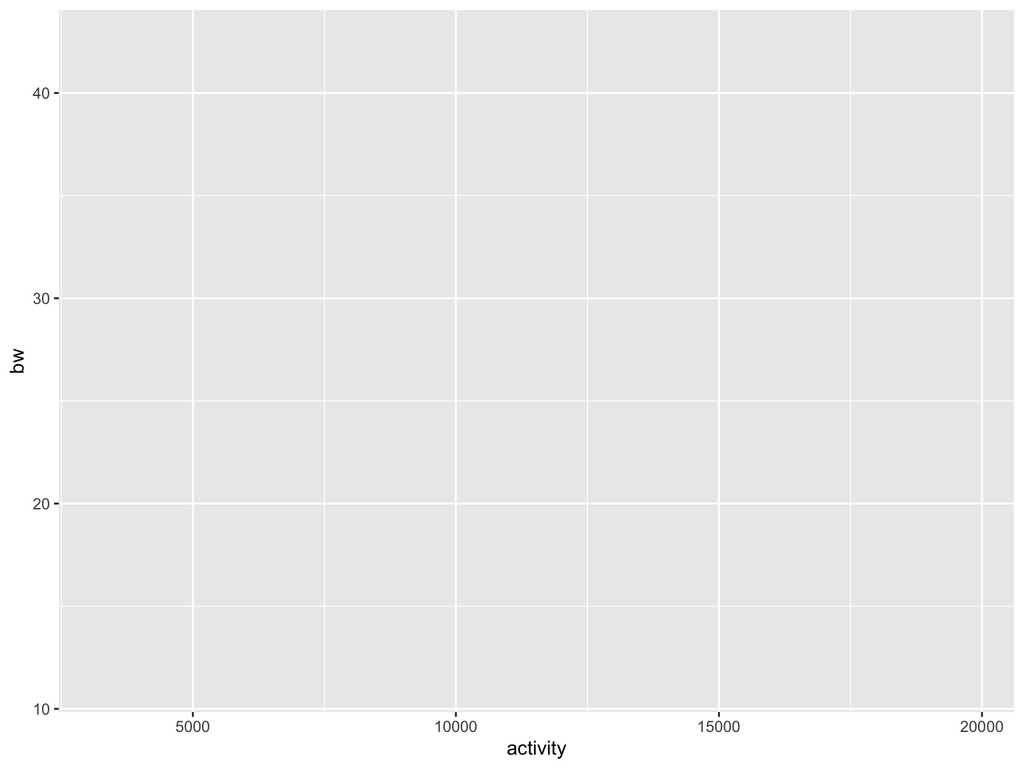

```r
pic <- ggplot(crusio1, aes(x = activity, y = bw))
pic
```

When we run this, nothing happens, or seems to happen.

# GGPlot2 Step 2

We next need to add a layer that tells R what sort of shape to map those aesthetic attributes onto:

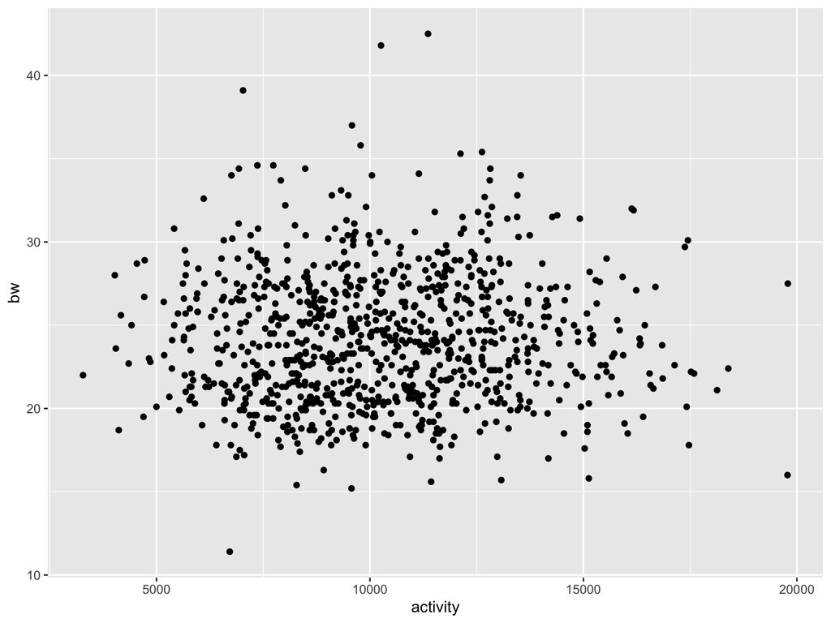

```r
pic + geom_point()
```

# A different Geom

We could try a different “geom” but most do not actually make a lot of sense for this combination of variables:

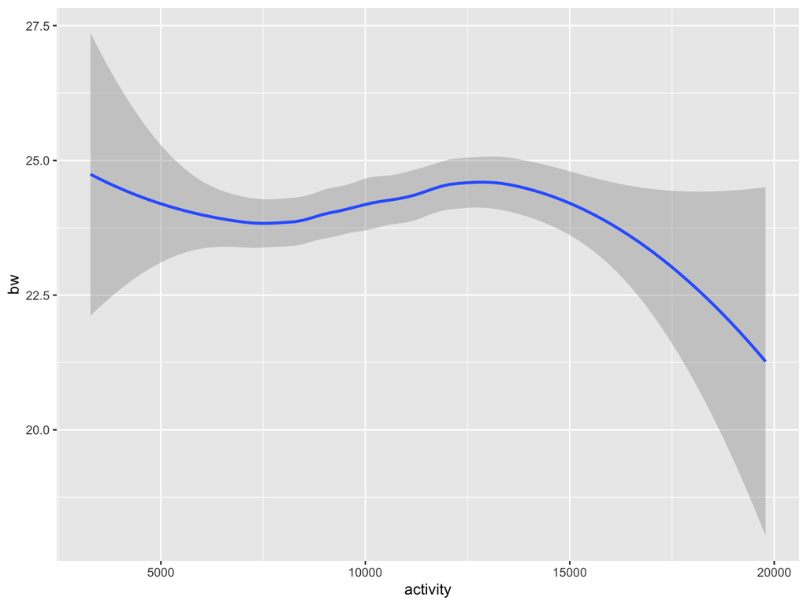

```r
pic + geom_smooth()
```

There is **no need* to memorize these “geoms.” Instead go to the Help up on the top menu and open the Cheatsheets. There are many cheatsheets, and they add when you install packages. This is a quick reference guide.

# Combining Geoms

We can combine these geoms to get a scatter plot with a fit line. Method = “lm” is an argument

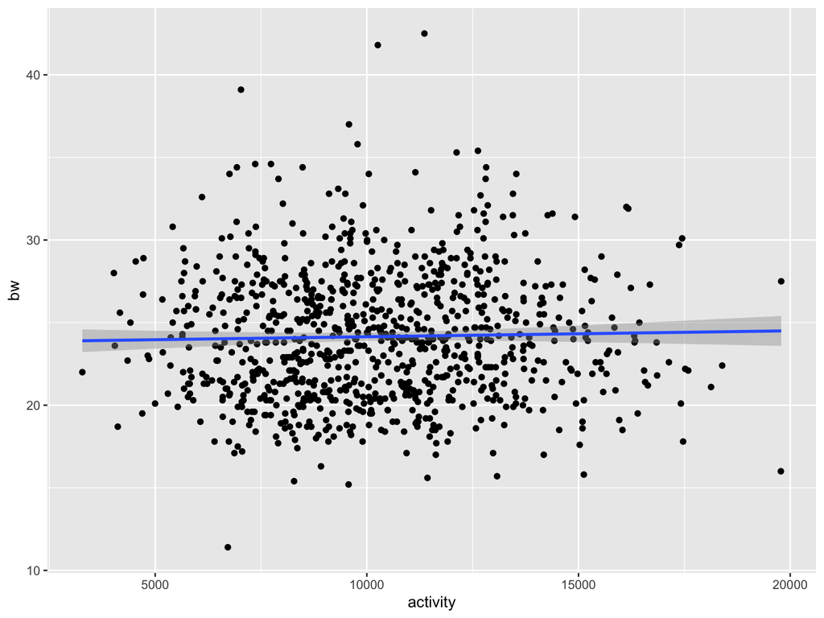

```r
pic + geom_point() + geom_smooth(method="lm")
```

# Group Work

Try making a chart with both points and a line for center time vs center distance.

# GGPlot 2 Making Histograms and Boxplots

So now if we want to make charts like those above we can:

Histograms

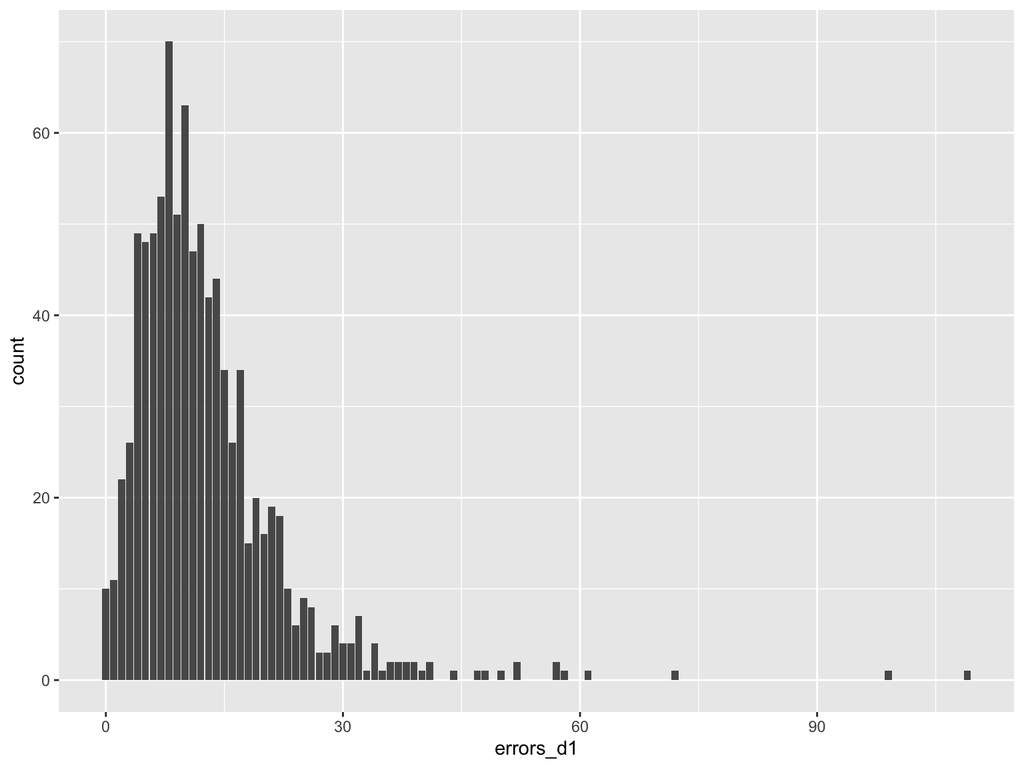

```r
ggplot(crusio1, aes(x = errors_d1, y = ..count..)) +geom_bar()
```

# Histogram Bins

We can also set the binwidth

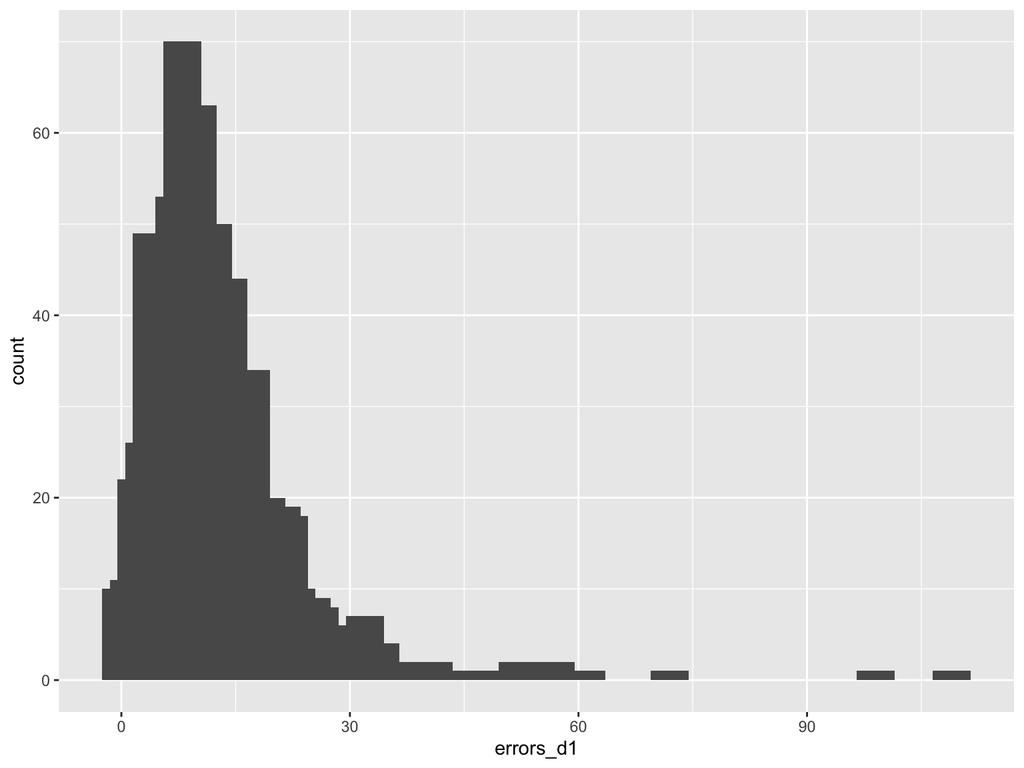

```r
ggplot(crusio1, aes(x = errors_d1, y = ..count..)) +geom_bar(width = 5)
```

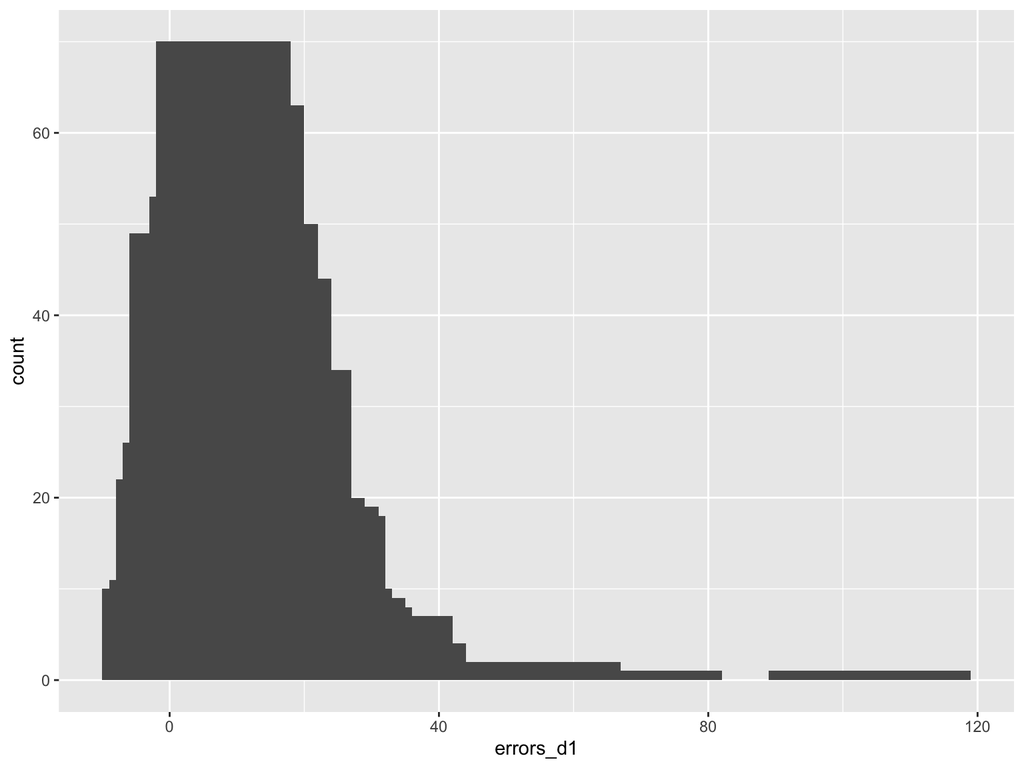

```r
ggplot(crusio1, aes(x = errors_d1, y = ..count..)) +geom_bar(width = 20)
```

# Boxplots

For boxplots

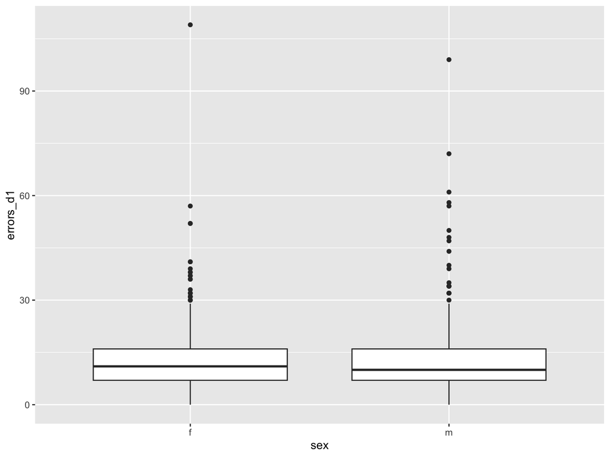

```r
ggplot(crusio1, aes(x = sex, y =errors_d1 ))+geom_boxplot()
```

# Group work

Make a histogram of center distance travelled, experiment with updating the binwidth. Make a boxplot of body weight by attack combined.

# Error Bars

We can use a layer called stat_summary to add visualizations that are not derived from raw counts, like mean values or confidence intervals:

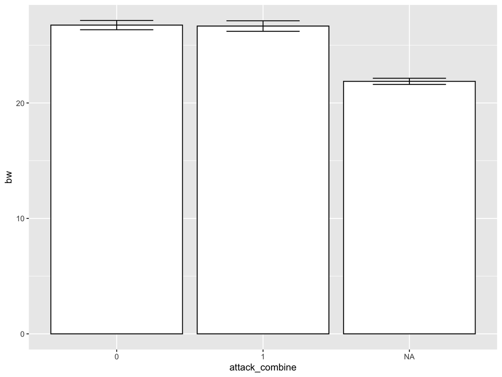

```r
crusio1$attack_combine <- factor(crusio1$attack_combine)
ggplot(crusio1, aes(x = attack_combine, y = bw)) + stat_summary(fun = mean, geom="bar",fill = "white", color = "black") + stat_summary(fun.data = mean_cl_normal, geom = "errorbar", width = .5)
```

# Group Work

Make a bar chart comparing the mean brainweight of attacking mice with error bars.

# GGPlot for formatting

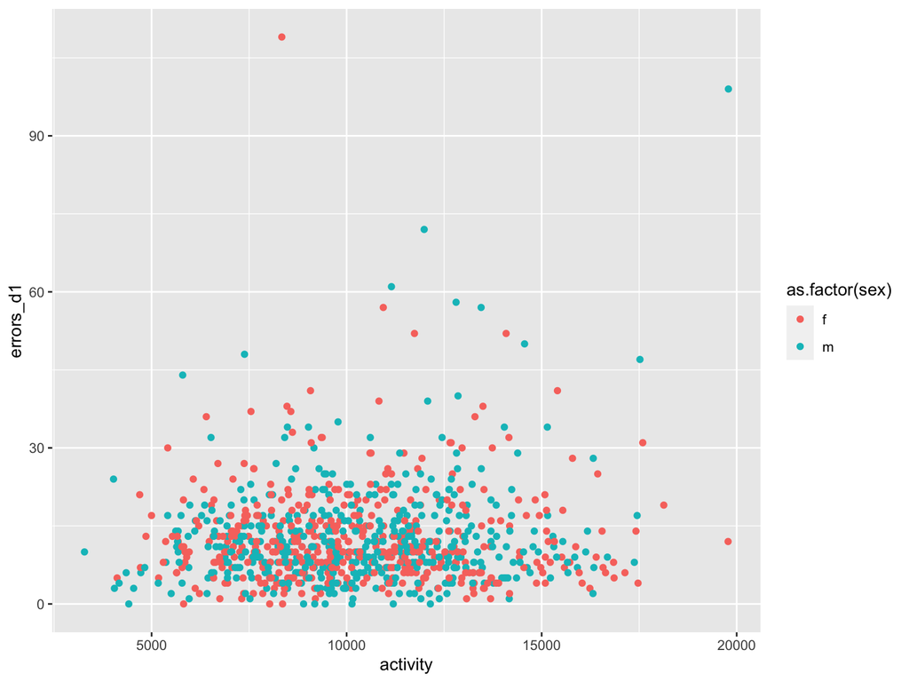

```r
ggplot(crusio1, aes(x = activity, y = errors_d1, col = as.factor(sex)))+geom_point()
```

# Color continued

A quirk of ggplot is that colors of points are encoded col, but if you want bars to be filled, you must use fill:

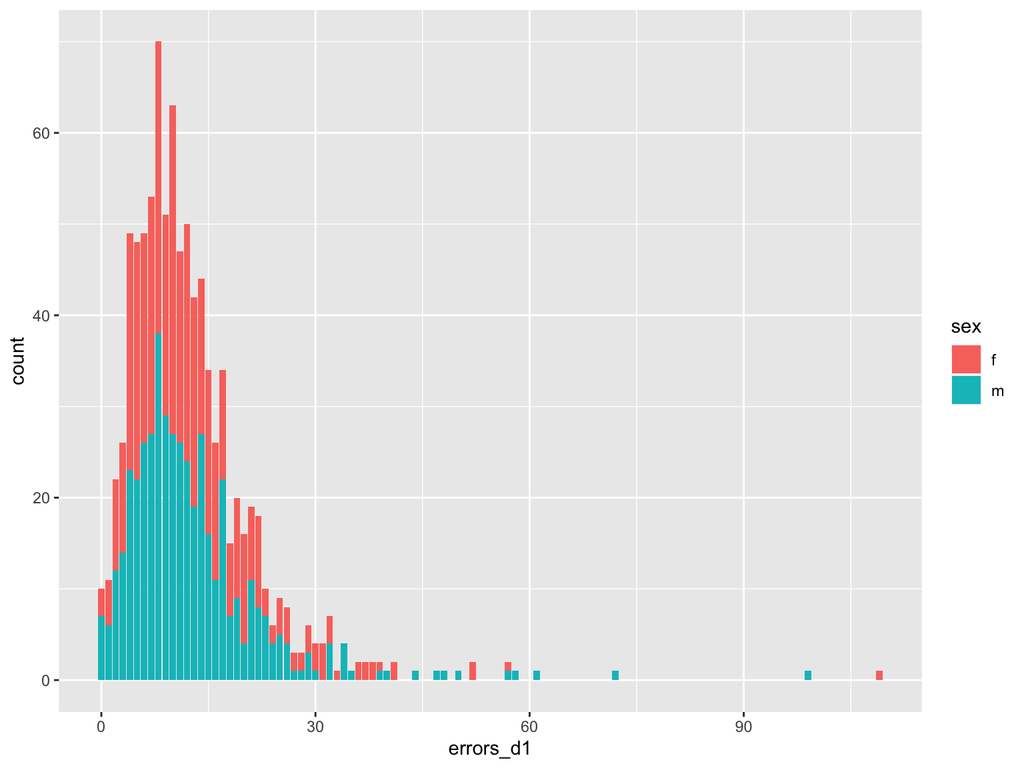

```r
ggplot(crusio1, aes(x = errors_d1, y = ..count.., fill = sex)) +geom_bar(binwidth = 10)
```

# Color Palettes

You can also use color blind friendly palettes, like those offered by the package colorbrewer2

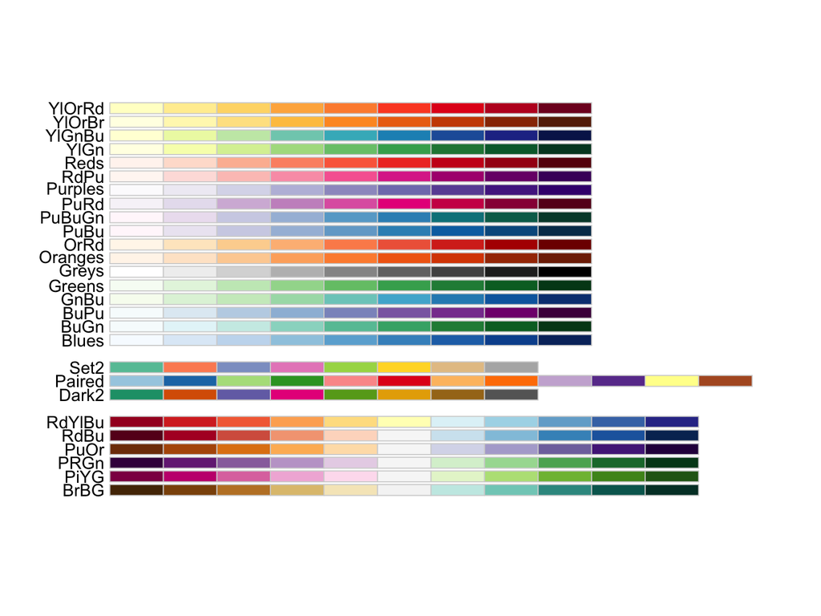

```r
#install.packages("RColorBrewer", repos = "http://cran.us.r-project.org")
library(RColorBrewer)
display.brewer.all(colorblindFriendly = TRUE)
```

Then:

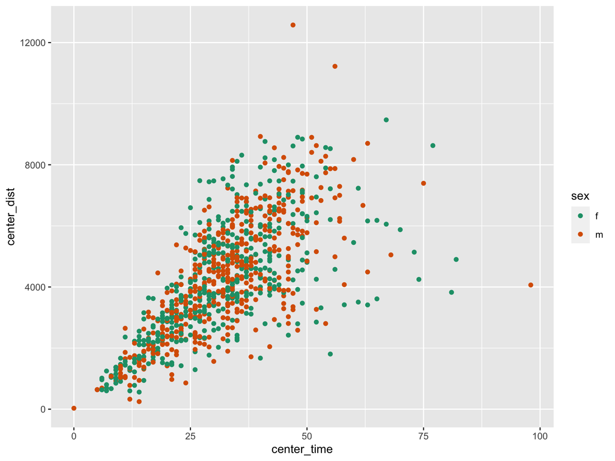

```r
ggplot(crusio1, aes(x = center_time, y = center_dist, col = sex))+geom_point() + scale_color_brewer(palette = "Dark2")
```

# Group Work

Explore the color brewer scales. Try using “display.brewer.all(colorblindFriendly = T)” to see the color blind friendly palettes. Add a color blind friendly palette to a chart of activity time vs. center distance, coloring by if they attacked or not (attack_combine)

# Scales

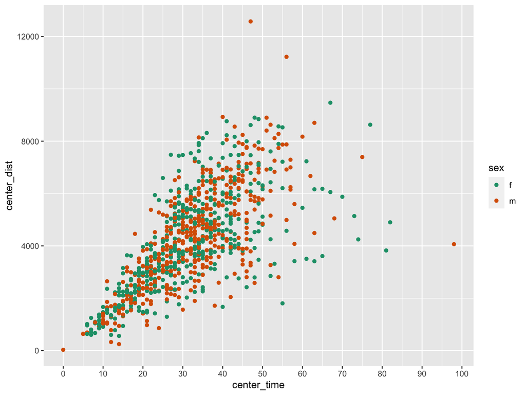

```r
ggplot(crusio1, aes(x = center_time, y = center_dist, col = sex))+geom_point() + scale_color_brewer(palette = "Dark2") + scale_x_continuous(breaks = seq(0, 100, 10))
```

We could do the same for the y scale:

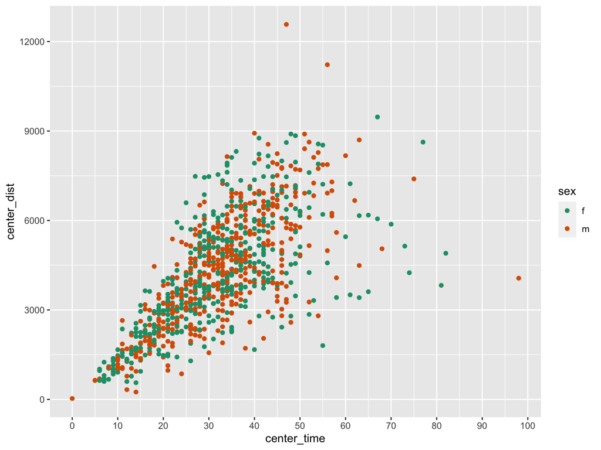

```r
ggplot(crusio1, aes(x = center_time, y = center_dist, col = sex))+geom_point() + scale_color_brewer(palette = "Dark2") + scale_x_continuous(breaks = seq(0, 100, 10))+scale_y_continuous(breaks = seq(0, 12000, 3000))
```

# Group Work

Make a chart of activity time vs. center distance and adjust the x access to have labeled breaks in increments of 2500 and the Y access in increments of 2000.

# Labels

We can also relabel the labels to make it more presentable for a paper, poster or talk. Perhaps you are noticing a trend that at first seems strange in ggplot but makes life easier: we keep making changes by adding arguments on to the end. This means once you get your baseline plot drawn you can then experiment on customizing for publication.

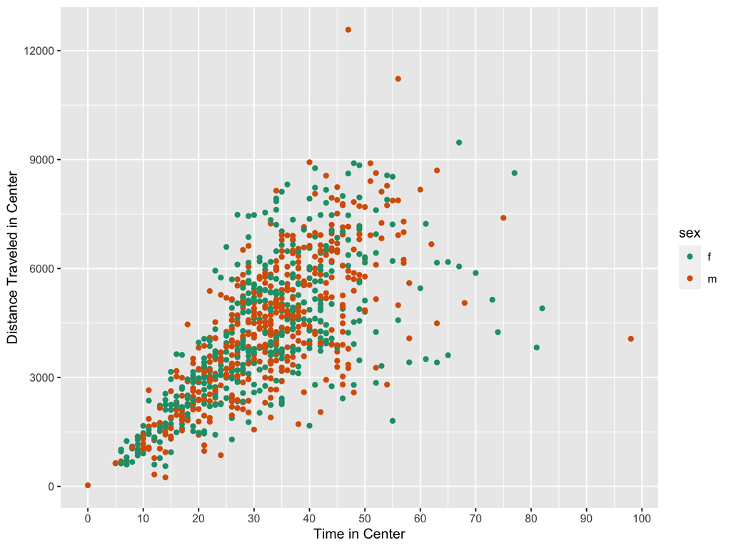

```r
ggplot(crusio1, aes(x = center_time, y = center_dist, col = sex))+geom_point() + scale_color_brewer(palette = "Dark2") + scale_x_continuous(breaks = seq(0, 100, 10))+scale_y_continuous(breaks = seq(0, 12000, 3000)) + xlab("Time in Center") + ylab("Distance Traveled in Center")
```

# Themes

We can also customize the overall “look” of the chart with a theme. As you start adding “theme_” R will suggest options, try them out to see which you like. The second theme argument removes a redundant label on the legend.

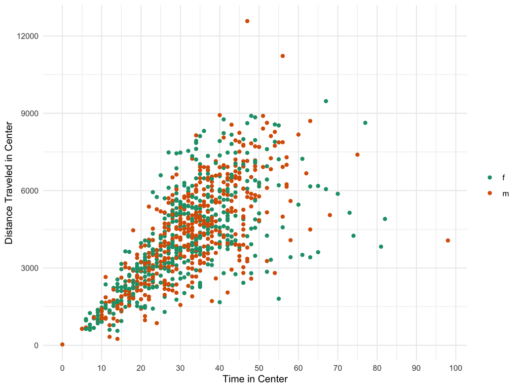

```r
ggplot(crusio1, aes(x = center_time, y = center_dist, col = sex))+geom_point() + scale_color_brewer(palette = "Dark2") + scale_x_continuous(breaks = seq(0, 100, 10))+scale_y_continuous(breaks = seq(0, 12000, 3000)) + xlab("Time in Center") + ylab("Distance Traveled in Center") + theme_minimal() + theme(legend.title = element_blank())
```

# Group Work

Copy your last chart and try out some of the themes available in Ggplot to update the background. What contexts would you want a lighter vs a darker background?

# Things to consider when choosing colors and themes

- Accessibility (color blind friendly palettes can help).
- Where will this be seen? Large rooms like conference plenaries, might benefit from a dark background with light points, bright rooms with slide projectors will benefit from light backgrounds and dark points.
- Posters assume that readers have limited time and need a simple message.
- In journal papers provide enough information that a user can understand without flipping to additional information.
- Avoid gimmicks like 3D designs.